# The carbon footprint of nations: analisi dei dati OWID CO2

Samuele Antonello 162640, Tommaso Trentin 167340, Marco Ungaro …

27/11/2026

# 0. Obiettivo e struttura del lavoro

In questo documento analizziamo il dataset **Our World in Data (OWID) – CO₂ and Greenhouse Gas Emissions**, che raccoglie le emissioni di CO₂ di paesi e regioni del mondo per più di due secoli.

Il lavoro segue la *pipeline* standard della data science:

1. **Importazione**: leggiamo il file CSV in R.
2. **Pulizia**: selezioniamo le colonne utili, separiamo i *paesi* dagli *aggregati* (mondo, continenti) e verifichiamo l’assenza di doppi conteggi.
3. **Analisi descrittiva**: calcoliamo le statistiche di sintesi per osservare la disuguaglianza tra paesi, in termini totali e pro capite.
4. **Visualizzazione**: costruiamo quattro grafici con `ggplot2` (responsabilità cumulativa, peso pro capite, dinamica per continente e mix dei combustibili).
5. **Comunicazione / arte dei dati**: traduciamo i dati in parametri sonori (altezza, volume, durata, mix dei combustibili) per alimentare il nostro *sampler* interattivo basato sull’**udito**.
6. **Riflessione critica**: discutiamo cosa aggiunge la data art alla visualizzazione convenzionale e il ruolo della comprensione emotiva.

Unità di misura da ricordare: `co2` è in **milioni di tonnellate (Mt)**, `co2_per_capita` in **tonnellate per persona**, `cumulative_co2` in **milioni di tonnellate** accumulate dal 1750 a oggi.

# 1. Importazione dei dati

Carichiamo `tidyverse` (che include `readr`, `dplyr`, `ggplot2`, `tidyr`, `forcats`) e `jsonlite`, usato alla fine per esportare i parametri del sampler in formato JSON. Il file `owid_co2.csv` deve trovarsi **nella stessa cartella** di questo `.Rmd`.

```r
library(tidyverse)
library(jsonlite)

raw_data <- read_csv("owid_co2.csv")
```

Il dataset contiene **56269 righe** e **79 colonne**, con osservazioni che vanno dal **1750** al **2025**. Ogni riga corrisponde a *una nazione o regione in un certo anno*. Prima di analizzarlo dobbiamo pulirlo.

# 2. Pulizia dei dati

## 2.1 Selezione delle colonne

Le colonne originali sono 79, ma per la nostra analisi ne servono 10: chi (`country`, `iso_code`), quando (`year`), quanti sono (`population`) e quanto emettono (`co2`, `co2_per_capita`, `cumulative_co2` e le tre principali fonti fossili `coal_co2`, `oil_co2`, `gas_co2`).

```r
data_selected <- raw_data |>
  select(
    country, iso_code, year, population,
    co2, co2_per_capita, cumulative_co2,
    coal_co2, oil_co2, gas_co2
  )
```

## 2.2 Paesi veri e aggregati: evitare i doppi conteggi

Nella colonna `country` non ci sono solo i singoli stati, ma anche aggregati come `"World"`, `"Europe"`, `"Asia"` o gruppi di reddito: mescolandoli ai paesi conteremmo le stesse emissioni più volte. Gli aggregati non hanno un `iso_code`, quindi teniamo solo le righe con codice presente.

*Nota sui limiti del filtro:* restano esclusi i pochissimi territori privi di codice ISO (come il Kosovo) e le voci non attribuite a singoli stati (aviazione e navigazione internazionali). Per i totali globali useremo quindi sempre la riga `World`.

```r
data_countries <- data_selected |>
  filter(!is.na(iso_code)) |>
  mutate(
    across(
      c(coal_co2, oil_co2, gas_co2),
      \(x) if_else(is.na(x) & !is.na(co2), 0, x)
    )
  )

tibble(
  Righe = nrow(data_countries),
  Paesi_e_territori = n_distinct(data_countries$country),
  Codici_ISO = n_distinct(data_countries$iso_code)
) |>
  knitr::kable()
```

| Righe | Paesi_e_territori | Codici_ISO |
| --- | --- | --- |
| 48306 | 223 | 223 |

Per i tre combustibili (carbone, petrolio, gas), dove il totale `co2` è noto ma il singolo combustibile è `NA`, assumiamo “nessuna emissione registrata” e sostituiamo con `0`. Dove manca anche `co2`, lasciamo `NA` per non inventare dati inesistenti. Va ricordato inoltre che `coal_co2 + oil_co2 + gas_co2` copre circa il **94%** del totale mondiale del 2025: il restante ~6% deriva da cemento, flaring e altri processi industriali.

## 2.3 Dataset separato per mondo e continenti

Creiamo una tabella separata con **solo gli aggregati geografici** principali (`World` e i sei continenti), così da confrontare le grandi aree senza sommare i paesi a mano e senza rischio di doppi conteggi.

```r
continents_list <- c(
  "World", "Africa", "Asia", "Europe",
  "North America", "South America", "Oceania"
)

data_continents <- data_selected |>
  filter(country %in% continents_list)

data_continents |>
  distinct(country) |>
  knitr::kable(col.names = "Aggregati selezionati")
```

| Aggregati selezionati |
| --- |
| Africa |
| Asia |
| Europe |
| North America |
| Oceania |
| South America |
| World |

# 3. Statistiche descrittive

Partiamo dall’ultimo anno disponibile (**2025**) per misurare quanto le emissioni siano distribuite in modo disuguale tra i paesi. Indichiamo sia il totale delle righe con codice ISO (`Paesi`) sia i paesi con un valore di `co2` effettivamente disponibile (`Paesi_con_CO2`, poiché 3 microstati — Monaco, San Marino e Vaticano — hanno `NA`).

```r
data_countries |>
  filter(year == 2025) |>
  summarise(
    Paesi = n(),
    Paesi_con_CO2 = sum(!is.na(co2)),
    Media_CO2_Mt = mean(co2, na.rm = TRUE),
    Mediana_CO2_Mt = median(co2, na.rm = TRUE),
    Max_CO2_Mt = max(co2, na.rm = TRUE),
    Media_ProCapite_t = mean(co2_per_capita, na.rm = TRUE),
    Mediana_ProCapite_t = median(co2_per_capita, na.rm = TRUE)
  ) |>
  knitr::kable(digits = 2)
```

| Paesi | Paesi_con_CO2 | Media_CO2_Mt | Mediana_CO2_Mt | Max_CO2_Mt | Media_ProCapite_t | Mediana_ProCapite_t |
| --- | --- | --- | --- | --- | --- | --- |
| 223 | 220 | 171.58 | 10.19 | 12417.49 | 4.51 | 3.12 |

**Come leggere la tabella.** La *media* delle emissioni totali (`171,6 Mt`) è quasi **17 volte più alta** della *mediana* (`10,2 Mt`): pochissime nazioni emettono volumi enormi e trascinano la media verso l’alto, mentre la metà dei paesi emette meno di 10 Mt l’anno. È la prima prova numerica di una distribuzione fortemente asimmetrica.

Vediamo i cinque maggiori emettitori annuali nel 2025:

```r
data_countries |>
  filter(year == 2025) |>
  slice_max(co2, n = 5) |>
  transmute(
    Paese = country,
    CO2_Mt = co2,
    CO2_pro_capite_t = co2_per_capita,
    Popolazione_M = population / 1e6
  ) |>
  knitr::kable(digits = 2)
```

| Paese | CO2_Mt | CO2_pro_capite_t | Popolazione_M |
| --- | --- | --- | --- |
| China | 12417.49 | 8.77 | 1416.10 |
| United States | 5035.56 | 14.50 | 347.28 |
| India | 3203.41 | 2.19 | 1463.87 |
| Russia | 1766.67 | 12.27 | 144.00 |
| Japan | 960.24 | 7.80 | 123.10 |

# 4. Visualizzazioni

## 4.1 Chi ha emesso di più nella storia?

Le emissioni *annuali* fotografano il presente, ma il riscaldamento globale dipende da **tutta la CO₂ accumulata** in atmosfera nel tempo. Guardiamo quindi le emissioni **cumulative** dal 1750 al 2025 (convertite da milioni a **miliardi** di tonnellate, Gt) per i 10 paesi storicamente più responsabili.

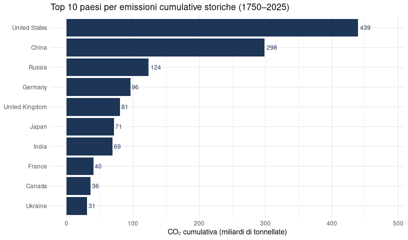

```r
data_countries |>
  filter(year == 2025, !is.na(cumulative_co2)) |>
  slice_max(cumulative_co2, n = 10) |>
  mutate(cumulative_gt = cumulative_co2 / 1000) |>
  ggplot(aes(x = fct_reorder(country, cumulative_gt), y = cumulative_gt)) +
  geom_col(fill = "#1d3557") +
  geom_text(
    aes(label = round(cumulative_gt, 0)),
    hjust = -0.2,
    size = 3.2,
    color = "#1d3557"
  ) +
  coord_flip() +
  expand_limits(y = 485) +
  labs(
    title = "Top 10 paesi per emissioni cumulative storiche (1750–2025)",
    x = NULL,
    y = "CO₂ cumulativa (miliardi di tonnellate)"
  ) +
  theme_minimal()
```

Mentre nel 2025 la Cina è il primo emettitore annuale, sul piano **storico** gli Stati Uniti restano nettamente primi (`439 Gt`), seguiti da Cina (`298 Gt`), Russia (`124 Gt`) e paesi europei di antica industrializzazione come Germania e Regno Unito.

## 4.2 Emissioni pro capite: il peso del singolo cittadino

Un paese può emettere molto perché è molto popoloso o perché ogni abitante ha un’impronta elevata. Il grafico seguente separa i due effetti (limitandosi ai paesi con oltre 1 milione di abitanti per evitare distorsioni da piccoli stati insulari o città-stato):

- asse **x**: popolazione in scala logaritmica;
- asse **y**: tonnellate di CO₂ **per persona** (la linea tratteggiata indica la media mondiale 2025);
- **dimensione** del punto: emissioni totali del paese.

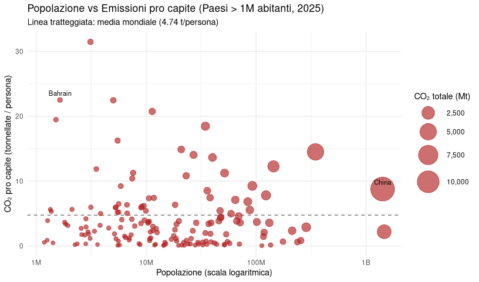

```r
world_pc_2025 <- data_continents |>
  filter(country == "World", year == 2025) |>
  pull(co2_per_capita)

data_countries |>
  filter(year == 2025, !is.na(co2_per_capita), !is.na(population), population > 1e6) |>
  mutate(
    label = if_else(
      co2 > 1500 | co2_per_capita > 18 | country == "Italy",
      country,
      ""
    )
  ) |>
  ggplot(aes(x = population, y = co2_per_capita, size = co2)) +
  geom_hline(yintercept = world_pc_2025, linetype = "dashed", color = "grey45") +
  geom_point(alpha = 0.65, color = "#b22222") +
  geom_text(aes(label = label), vjust = -0.8, size = 3, check_overlap = TRUE) +
  scale_x_log10(labels = scales::label_number(scale_cut = scales::cut_short_scale())) +
  scale_size_continuous(range = c(2, 14), labels = scales::comma) +
  labs(
    title = "Popolazione vs Emissioni pro capite (Paesi > 1M abitanti, 2025)",
    subtitle = paste0("Linea tratteggiata: media mondiale (", round(world_pc_2025, 2), " t/persona)"),
    x = "Popolazione (scala logaritmica)",
    y = "CO₂ pro capite (tonnellate / persona)",
    size = "CO₂ totale (Mt)"
  ) +
  theme_minimal()
```

Il confronto tra **India** (`2,2 t/persona` ma `3.203 Mt` totali) e paesi del Golfo come **Qatar** (`31,5 t/persona`) o **Stati Uniti** (`14,5 t/persona`) rende evidente la differenza tra peso demografico e intensità individuale. L’Italia (`5,0 t/persona`) si colloca appena sopra la media mondiale (`4,7 t/persona`).

## 4.3 Come sono cambiate le emissioni dei continenti

Osserviamo ora la **dinamica temporale** delle emissioni annuali per continente dal 1950 al 2025 (escludendo `World` per non schiacciare le altre curve).

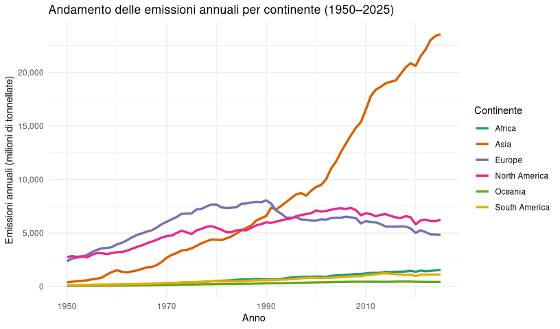

```r
data_continents |>
  filter(country != "World", year >= 1950) |>
  ggplot(aes(x = year, y = co2, color = country)) +
  geom_line(linewidth = 1.2) +
  scale_color_brewer(palette = "Dark2") +
  scale_y_continuous(labels = scales::comma) +
  labs(
    title = "Andamento delle emissioni annuali per continente (1950–2025)",
    x = "Anno",
    y = "Emissioni annuali (milioni di tonnellate)",
    color = "Continente"
  ) +
  theme_minimal()
```

## 4.4 La trasformazione del mix di combustibili

Per collegare l’analisi statistica alla dimensione timbrica della nostra opera sonora, visualizziamo infine come è cambiato il contributo globale di **carbone**, **petrolio** e **gas naturale** dal 1900 al 2025.

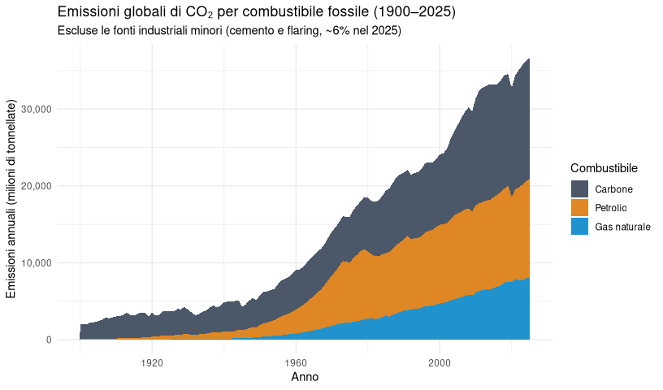

```r
data_continents |>
  filter(country == "World", year >= 1900) |>
  select(year, coal_co2, oil_co2, gas_co2) |>
  pivot_longer(
    cols = c(coal_co2, oil_co2, gas_co2),
    names_to = "fuel",
    values_to = "co2"
  ) |>
  mutate(
    fuel = factor(
      fuel,
      levels = c("coal_co2", "oil_co2", "gas_co2"),
      labels = c("Carbone", "Petrolio", "Gas naturale")
    )
  ) |>
  ggplot(aes(x = year, y = co2, fill = fuel)) +
  geom_area(alpha = 0.88) +
  scale_fill_manual(
    values = c("Carbone" = "#334155", "Petrolio" = "#d97706", "Gas naturale" = "#0284c7")
  ) +
  scale_y_continuous(labels = scales::comma) +
  labs(
    title = "Emissioni globali di CO₂ per combustibile fossile (1900–2025)",
    subtitle = "Escluse le fonti industriali minori (cemento e flaring, ~6% nel 2025)",
    x = "Anno",
    y = "Emissioni annuali (milioni di tonnellate)",
    fill = "Combustibile"
  ) +
  theme_minimal()
```

Nel 1900 il carbone rappresentava quasi la totalità delle emissioni mondiali (`95,7%`). Tra il 1968 e il 2004 il petrolio diventa la prima fonte, prima che il carbone torni in testa dal 2005 con la rapida industrializzazione asiatica. Nel frattempo il gas naturale cresce in modo costante fino al `20,7%` del totale mondiale del 2025: una transizione non sostitutiva, ma *additiva*, in cui ogni nuova fonte si somma alle precedenti.

# 5. Dai dati al suono: parametri per il Data-driven sampler

Passiamo dalla parte analitica a quella **artistica**. L’idea è che ogni coppia *continente + anno* diventi **un suono** (un “pad” del sampler). Le caratteristiche del suono derivano direttamente dai dati, così che **ascoltare** significhi **confrontare** epoche e aree del pianeta.

## 5.1 Quali regioni e quali anni

Scegliamo 4 continenti (`Europe`, `North America`, `Asia`, `Africa`) e 4 anni-chiave, per un totale di **16 pad**:

- **1900**: l’industrializzazione europea e nordamericana a base di carbone;
- **1950**: il dopoguerra e l’inizio della grande accelerazione;
- **1990**: l’anno di riferimento dei primi trattati internazionali sul clima;
- **2025**: il presente.

## 5.2 Come i dati diventano suono

Ad ogni variabile del dataset associamo una **dimensione sonora** distinta:

| Dato | Parametro sonoro | Significato percettivo |
| --- | --- | --- |
| `co2_per_capita` | **altezza** (frequenza in Hz) | Più ogni abitante emette, più il suono sale di registro e diventa teso |
| `co2` (annuale) | **volume** (`gain_norm`) | Più sono alte le emissioni totali, più il suono ha presenza e peso |
| `cumulative_co2` | **durata** (`decay_sec`) | La CO₂ resta in atmosfera per secoli: più è accumulata, più il suono si prolunga |
| `coal_co2`, `oil_co2`, `gas_co2` | **timbro / carattere** | Combustibile dominante e quote relative definiscono la “voce” energetica del pad |

Scelte tecniche principali:

- **Normalizzazione interna**: i massimi sono calcolati sulle 16 righe selezionate, così tutti i 16 pad sono direttamente confrontabili tra loro sull’intera estensione dello strumento.
- **Radice quadrata per il volume**: i totali variano di oltre quattro ordini di grandezza (dai `2,3 Mt` dell’Africa 1900 ai `23.572 Mt` dell’Asia 2025). La radice quadrata con soglia minima `0.2` evita che i valori più bassi spariscano pur preservando la gerarchia dei volumi.
- **Estensione di frequenza**: da `65 Hz` (circa Do2) a `585 Hz`, pari a poco più di 3 ottave (`log2(585/65) ≈ 3,17`).
- **Frequenza lineare in Hz o lineare in semitoni?** L’orecchio percepisce l’altezza in modo **logaritmico rispetto agli Hz** (in ottave e semitoni, non in differenze di Hz). Una mappatura lineare in Hz (`freq_hz`) dilata le differenze vicine allo zero e comprime quelle in alto. Per questo calcoliamo `freq_hz_log`, che cresce esponenzialmente in Hz ed è quindi **lineare in semitoni**: ogni `+1 t/persona` alza il suono sempre dello stesso intervallo musicale (**~2,7 semitoni**). È l’equivalente sonoro di un asse lineare in un grafico, e restituisce fedelmente all’orecchio la disuguaglianza pro capite senza distorcerla.
- **Quote dei combustibili**: oltre al `dominant_fuel`, esportiamo anche le quote percentuali `coal_share`, `oil_share` e `gas_share`. Infatti il gas naturale non risulta mai primo in nessuno dei 16 pad (pur raggiungendo ~38% in Europa e Nord America nel 2025): avere le tre quote permette al sampler di far emergere l’intero mix energetico.

```r
target_regions <- c("Europe", "North America", "Asia", "Africa")
target_years <- c(1900, 1950, 1990, 2025)
freq_min <- 65
freq_max <- 585

sampler_pads <- data_continents |>
  filter(country %in% target_regions, year %in% target_years) |>
  mutate(
    across(c(coal_co2, oil_co2, gas_co2), \(x) replace_na(x, 0)),
    country = factor(country, levels = target_regions),
    fuel_total = coal_co2 + oil_co2 + gas_co2,

    # quote relative dei tre combustibili principali
    coal_share = round(if_else(fuel_total > 0, coal_co2 / fuel_total, 0), 3),
    oil_share = round(if_else(fuel_total > 0, oil_co2 / fuel_total, 0), 3),
    gas_share = round(if_else(fuel_total > 0, gas_co2 / fuel_total, 0), 3),

    # combustibile prevalente
    dominant_fuel = case_when(
      fuel_total == 0 ~ "unknown",
      coal_co2 >= oil_co2 & coal_co2 >= gas_co2 ~ "coal",
      oil_co2 >= coal_co2 & oil_co2 >= gas_co2 ~ "oil",
      .default = "gas"
    ),

    # normalizzazioni sui 16 pad
    pc_norm = co2_per_capita / max(co2_per_capita, na.rm = TRUE),
    co2_norm = sqrt(co2) / sqrt(max(co2, na.rm = TRUE)),
    cum_norm = cumulative_co2 / max(cumulative_co2, na.rm = TRUE),

    # parametri sonori
    freq_hz = round(freq_min + pc_norm * (freq_max - freq_min), 1),
    freq_hz_log = round(freq_min * (freq_max / freq_min)^pc_norm, 1),
    gain_norm = round(0.2 + 0.8 * co2_norm, 3),
    decay_sec = round(0.25 + 2.2 * cum_norm, 2)
  ) |>
  arrange(country, year) |>
  select(
    country, year, co2, co2_per_capita, cumulative_co2,
    dominant_fuel, coal_share, oil_share, gas_share,
    freq_hz, freq_hz_log, gain_norm, decay_sec
  )

sampler_pads |>
  knitr::kable()
```

| country | year | co2 | co2_per_capita | cumulative_co2 | dominant_fuel | coal_share | oil_share | gas_share | freq_hz | freq_hz_log | gain_norm | decay_sec |
| --- | --- | --- | --- | --- | --- | --- | --- | --- | --- | --- | --- | --- |
| Europe | 1900 | 1209.566 | 3.008 | 33296.828 | coal | 0.972 | 0.028 | 0.000 | 175.5 | 103.7 | 0.381 | 0.36 |
| Europe | 1950 | 2376.510 | 4.328 | 115961.781 | coal | 0.877 | 0.114 | 0.009 | 224.0 | 127.2 | 0.454 | 0.64 |
| Europe | 1990 | 8051.915 | 11.112 | 346284.312 | coal | 0.390 | 0.383 | 0.226 | 473.1 | 364.6 | 0.668 | 1.42 |
| Europe | 2025 | 4844.096 | 6.499 | 556620.625 | oil | 0.204 | 0.421 | 0.375 | 303.7 | 178.2 | 0.563 | 2.14 |
| North America | 1900 | 689.307 | 6.680 | 11017.021 | coal | 0.947 | 0.036 | 0.017 | 310.3 | 183.3 | 0.337 | 0.29 |
| North America | 1950 | 2747.712 | 12.458 | 98348.586 | coal | 0.507 | 0.371 | 0.122 | 522.6 | 449.3 | 0.473 | 0.58 |
| North America | 1990 | 6000.515 | 14.158 | 274317.938 | oil | 0.330 | 0.463 | 0.207 | 585.0 | 585.0 | 0.604 | 1.18 |
| North America | 2025 | 6240.703 | 10.166 | 506290.906 | oil | 0.138 | 0.480 | 0.382 | 438.4 | 314.8 | 0.612 | 1.97 |
| Asia | 1900 | 43.980 | 0.047 | 419.582 | coal | 0.827 | 0.173 | 0.000 | 66.7 | 65.5 | 0.235 | 0.25 |
| Asia | 1950 | 396.917 | 0.290 | 12348.505 | coal | 0.781 | 0.204 | 0.014 | 75.7 | 68.0 | 0.304 | 0.29 |
| Asia | 1990 | 6598.799 | 2.056 | 129991.914 | coal | 0.525 | 0.375 | 0.100 | 140.5 | 89.4 | 0.623 | 0.69 |
| Asia | 2025 | 23572.430 | 4.876 | 649039.625 | coal | 0.602 | 0.242 | 0.156 | 244.1 | 138.5 | 1.000 | 2.45 |
| Africa | 1900 | 2.330 | 0.017 | 31.943 | coal | 1.000 | 0.000 | 0.000 | 65.6 | 65.2 | 0.208 | 0.25 |
| Africa | 1950 | 93.342 | 0.410 | 1737.115 | coal | 0.754 | 0.246 | 0.000 | 80.1 | 69.3 | 0.250 | 0.26 |
| Africa | 1990 | 660.986 | 1.027 | 15704.417 | coal | 0.476 | 0.402 | 0.123 | 102.7 | 76.2 | 0.334 | 0.30 |
| Africa | 2025 | 1558.322 | 1.007 | 55786.203 | oil | 0.325 | 0.444 | 0.230 | 102.0 | 76.0 | 0.406 | 0.44 |

## 5.3 Mappa visiva della griglia 4×4 del sampler

Prima di passare all’audio, visualizziamo la stessa griglia **4 anni × 4 continenti** che compone i 16 pad: la dimensione del cerchio rappresenta il volume (`gain_norm`), il colore il combustibile dominante e le etichette riportano altezza percettiva (`freq_hz_log`) e durata (`decay_sec`).

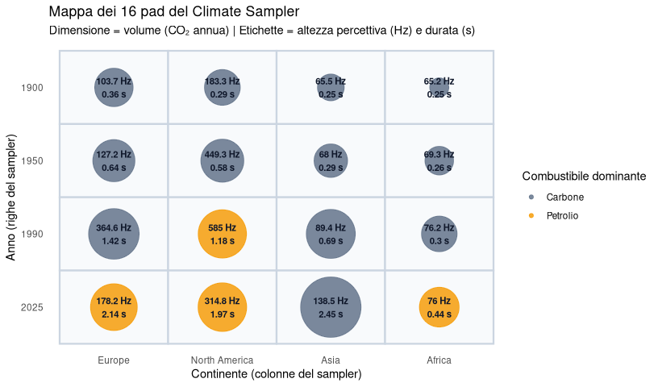

```r
sampler_pads |>
  mutate(year_f = factor(year, levels = rev(target_years))) |>
  ggplot(aes(x = country, y = year_f)) +
  geom_tile(fill = "#f8fafc", color = "#cbd5e1", linewidth = 0.8) +
  geom_point(aes(size = gain_norm, color = dominant_fuel), alpha = 0.85) +
  geom_text(
    aes(label = paste0(freq_hz_log, " Hz\n", decay_sec, " s")),
    size = 3,
    color = "#0f172a",
    fontface = "bold"
  ) +
  scale_size_continuous(range = c(8, 26), guide = "none") +
  scale_color_manual(
    values = c("coal" = "#64748b", "oil" = "#f59e0b", "gas" = "#0284c7"),
    labels = c("coal" = "Carbone", "oil" = "Petrolio", "gas" = "Gas")
  ) +
  labs(
    title = "Mappa dei 16 pad del Climate Sampler",
    subtitle = "Dimensione = volume (CO₂ annua) | Etichette = altezza percettiva (Hz) e durata (s)",
    x = "Continente (colonne del sampler)",
    y = "Anno (righe del sampler)",
    color = "Combustibile dominante"
  ) +
  theme_minimal() +
  theme(panel.grid = element_blank())
```

## 5.4 Controllo di qualità ed esportazione in JSON

Verifichiamo che non ci siano valori `NA` nei parametri sonori (la tabella deve avere **0 righe**) ed esportiamo il file `sampler_data.json` pronto per essere letto dal sampler.

```r
na_rows <- sampler_pads |>
  filter(if_any(everything(), is.na))

stopifnot(nrow(na_rows) == 0)

write_json(sampler_pads, "sampler_data.json", pretty = TRUE)
```

Il controllo è superato (0 righe con valori mancanti) e il file `sampler_data.json` è stato salvato correttamente.

## 5.5 Dagli oscillatori agli strumenti e al vinile (`sampler.html`)

Il file `sampler_data.json` alimenta direttamente la web app autonoma `sampler.html` (eseguibile anche offline nel browser tramite Web Audio API):

- **Un continente, uno strumento:** sopra ciascuna delle 4 colonne è possibile scegliere lo strumento sintetizzato (`Kick / Sub`, `Basso Analog`, `Snare / Perc + Hi-Hat`, `Synth / Rhodes`, `Hi-Hat / Shaker`), con default impostato per costruire un beat bilanciato (`Europa → Basso`, `Nord America → Synth`, `Asia → Kick`, `Africa → Percussioni`) e *panning* stereo geografico da Ovest a Est.
- **Fedeltà analitica e resa musicale:** un selettore permette di passare dalla modalità musicale (`Scala: Do minore`, con progressione armonica su 2 battute e accordi a 3 voci sul synth) alle frequenze pure (`Hz grezzi`) calcolate in R.
- **Gestione pulita della persistenza (`cumulative_co2`):** `decay_sec` regola la mandata verso un riverbero stereo e un delay sincronizzato ai BPM, mentre una saturazione analogica normalizzata (`tanh`) e un *Limiter* master (`DynamicsCompressorNode`) evitano qualsiasi distorsione digitale anche nei pattern più densi del 2025 e dello scenario proiettivo 2050.
- **Sequencer a 16 step e incisione del vinile:** oltre ai 5 preset storici (`86 → 140 BPM`) e alla modalità guidata `PLAY STORIA (1900→2050)`, il pulsante `INCIDI VINILE` registra un giro del loop e lo trasforma in un’immagine PNG 1200×1200 a forma di disco 33 giri, i cui solchi seguono l’onda sonora e il colore dell’etichetta riporta il mix carbone/petrolio/gas dell’epoca.

# 6. Domande finali

### 1. Può l’arte dei dati rivelare pattern che la visualizzazione convenzionale non mostra?

Sì, non perché i grafici tradizionali siano incompleti sul piano numerico, ma perché **vista e udito organizzano l’informazione in modo diverso**. Un grafico convenzionale congela il tempo sullo spazio: permette di leggere valori esatti, confrontare lunghezze e scorrere avanti e indietro con lo sguardo a proprio ritmo. Proprio per questo, però, tende ad appiattire la dimensione temporale e la simultaneità dei fenomeni.

Nel nostro sampler il suono mette in evidenza due aspetti difficili da “sentire” in una tabella o in un istogramma:

- **La persistenza cumulativa:** associando `cumulative_co2` alla durata del suono (`decay_sec`), le emissioni accumulate da Europa, Nord America e Asia nel 1990 e nel 2025 non si chiudono sul battito, ma continuano a risuonare e sovrapporsi ai suoni successivi. L’ascoltatore percepisce direttamente che la CO₂ emessa decenni fa è ancora presente in atmosfera.
- **L’accelerazione e la saturazione d’insieme:** passando dai pattern radi e puliti del 1900 alla densità del 2025, la crescita non appare come una semplice curva che sale verso l’angolo in alto a destra, ma come un cambiamento fisico di ritmo, affollamento e tensione acustica.

Resta vero l’inverso: a orecchio è quasi impossibile stimare se un valore sia `4.844 Mt` o `6.240 Mt`. La data art non sostituisce l’analisi statistica, ma rivela **dinamiche di durata, densità e contrasto** che nei grafici statici restano astratte.

### 2. La comprensione emotiva è una forma legittima di comprensione dei dati?

Sì, a una condizione precisa: che **l’emozione nasca dai dati e non li manipoli**. Davanti a cifre come `38.995 milioni di tonnellate` di CO₂ globali nel 2025 (o `23.572 Mt` per la sola Asia), la mente umana fatica a costruire un’immagine concreta — è il fenomeno noto in psicologia come *psychic numbing*: oltre una certa soglia, i numeri grandi diventano etichette astratte.

Tradurre quelle grandezze in un’esperienza sonora — un registro acuto che segnala l’impronta pro capite, un peso sonoro che schiaccia le voci più deboli, code lunghe che saturano lo spazio — trasforma una statistica in una percezione immediata e corporea. Capire *quanto* sia disuguale il divario tra `1,0 t/persona` in Africa e `14,2 t/persona` in Nord America, o *quanto* sia rapida l’accelerazione dal 1950 a oggi, significa anche coglierne il peso reale, non solo memorizzare due cifre.

Proprio perché l’impatto emotivo è potente, la trasparenza della mappatura diventa essenziale: scegliere una scala lineare in semitoni (`freq_hz_log`) invece di amplificare artificialmente i contrasti, e documentare ogni scelta nell’analisi R, garantisce che la risposta emotiva dell’ascoltatore resti ancorata alla realtà statistica del dataset.